# Coxph survival model

Jana Fischer

# Read in survival data

```r
library(data.table)
library(survival)
library(ggplot2)
library(broom)
library(dplyr)
surv_dat = fread('../../../data/survival_example_data.csv',header = TRUE)
head(surv_dat)
```

```
##    PID grade            Patientstatus OSmonth DFSmonth
## 1: 257     3                    alive     154       98
## 2:   7     3                    death      37       37
## 3: 166     3 death by primary disease      37       35
## 4: 238     1                    alive     233      140
## 5:  68     1                    alive     169      169
## 6:  72     3                    alive     186      186
```

Column description:  
PID: patient identifier  
grade: tumor pathology grade  
OSmonth: overall suvival from time of diagnosis [months]  
DFSmonth: disease free survival from time of diagnosis [months]  
Patientstatus: life/death status  
“death by primary disease” = death due to disease  
“death” = disease unrelated death  
“alive” = alive at given survival time  
“alive w metastases” = alive with metasatses at given survival time

# Prepare censoring information

Survival data is censored when the event has not yet occurred for a patient at a given time or the patient is lost to follow-up during the study. A more detailed explanation can be found here: http://www.sthda.com/english/wiki/survival-analysis-basics#censoring

```r
# Censoring for overall survival (1 = event (death due to disease), 0 = censored)
surv_dat[,censoringOS := 0]
surv_dat[Patientstatus == 'death by primary disease',censoringOS := 1]

# Censoring for disease free survival (1 = event (recurrence), 0 = censored)
surv_dat[ ,censoringDFS := 0]
surv_dat[ Patientstatus == 'alive w metastases',censoringDFS := 1]
surv_dat[ OSmonth > DFSmonth, censoringDFS := 1]
```

# Coxph survival model for grade groups

Covariates passed to the coxph model can be continuous or categorical. With categorical covariates each level is considered a distinct group and the first level is used as reference.

```r
# Set reference level for grade groups (first level)
surv_dat[,grade := factor(grade,levels = 1:3)]

# Calculate coxph model. The formula requires a standard survival object
# built with the Surv function from the "survival" package. In the survival
# object a plus behind the time indicates censoring.
res = coxph(Surv(OSmonth, censoringOS) ~ grade , data =  surv_dat)
summary(res)
```

```
## Call:
## coxph(formula = Surv(OSmonth, censoringOS) ~ grade, data = surv_dat)
##
##   n= 285, number of events= 58
##
##          coef exp(coef) se(coef)     z Pr(>|z|)
## grade2 1.2854    3.6163   0.7417 1.733  0.08307 .
## grade3 2.2194    9.2022   0.7274 3.051  0.00228 **
## ---
## Signif. codes:  0 '***' 0.001 '**' 0.01 '*' 0.05 '.' 0.1 ' ' 1
##
##        exp(coef) exp(-coef) lower .95 upper .95
## grade2     3.616     0.2765    0.8452     15.47
## grade3     9.202     0.1087    2.2119     38.28
##
## Concordance= 0.685  (se = 0.027 )
## Likelihood ratio test= 22.67  on 2 df,   p=1e-05
## Wald test            = 17.88  on 2 df,   p=1e-04
## Score (logrank) test = 21.67  on 2 df,   p=2e-05
```

The output contains:  
Pr(>|z|): Wald statistic of whether the coefficient is statistically significantly different from 0. Grade 3 is significant.  
coef: For the regression coefficients a positive sign represents higher risk of death and a negative sign lower risk. Grade 3 has a higher risk of death compared to grade 1.  
exp(coef): The exponent of the coefficient is the hazard ratio. Grade 3 patients have a risk that is increased by a factor of 9 compared to grade 1.  
The global statistical significance of the model can be found at the bottom of the output.

More detailed information and examples of multivariate cox regressions can be found here: http://www.sthda.com/english/wiki/cox-proportional-hazards-model

# Plot hazard ratios

```r
# The tidy function from the broom package summarizes and formats the output of the coxph
# function
td_res = tidy(res, exponentiate = TRUE)
print(td_res)
```

```
## # A tibble: 2 x 7
##   term   estimate std.error statistic p.value conf.low conf.high
##   <chr>     <dbl>     <dbl>     <dbl>   <dbl>    <dbl>     <dbl>
## 1 grade2     3.62     0.742      1.73 0.0831     0.845      15.5
## 2 grade3     9.20     0.727      3.05 0.00228    2.21       38.3
```

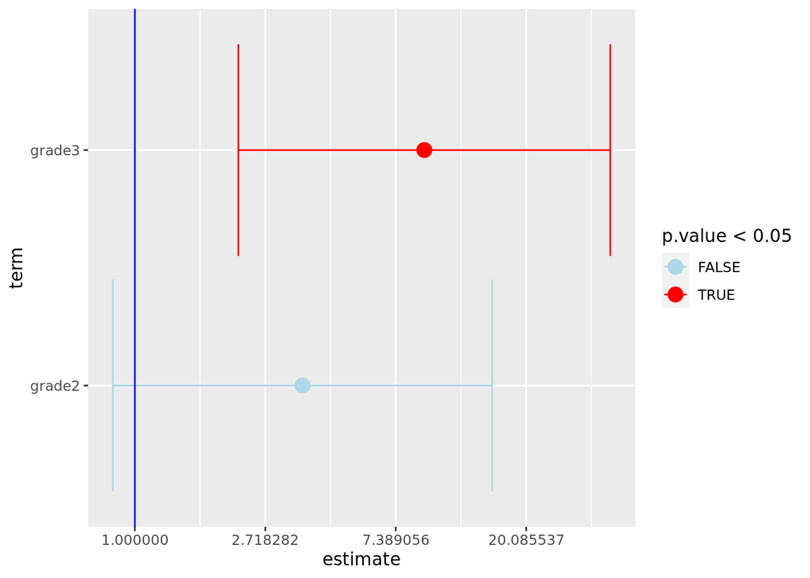

```r
# Make sure plot is ordered according to increasing HRs
td_res = td_res %>% arrange(estimate) %>% mutate(term = factor(term,levels = term))

# Visualize hazard ratios
ggplot(td_res, aes(x = term, y = estimate,color =p.value < 0.05)) +
geom_point(size = 4) +
geom_errorbar(aes(ymax = conf.high, ymin = conf.low))+
scale_color_manual(values = c('lightblue','red'))+
coord_flip()+
geom_hline(yintercept = 1,color = 'blue')+
scale_y_continuous(trans='log')
```